# Capstone Project on Credit Card Scoring

Aim: Predict which customers are good or bad.

Source: https://www.kaggle.com/datasets/rikdifos/credit-card-approval-prediction

## Metadata for Credit Records

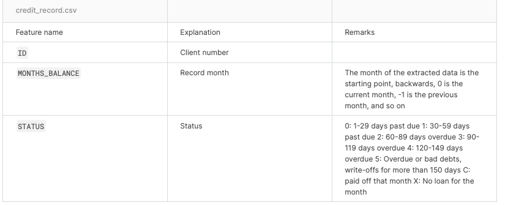

```python
import pandas as pd

crd_df=pd.read_csv('credit_record.csv')
crd_df.head(10)
```

|  | ID | MONTHS_BALANCE | STATUS |
| --- | --- | --- | --- |
| 0 | 5001711 | 0 | X |
| 1 | 5001711 | -1 | 0 |
| 2 | 5001711 | -2 | 0 |
| 3 | 5001711 | -3 | 0 |
| 4 | 5001712 | 0 | C |
| 5 | 5001712 | -1 | C |
| 6 | 5001712 | -2 | C |
| 7 | 5001712 | -3 | C |
| 8 | 5001712 | -4 | C |
| 9 | 5001712 | -5 | C |

## Meta Data for Application Records

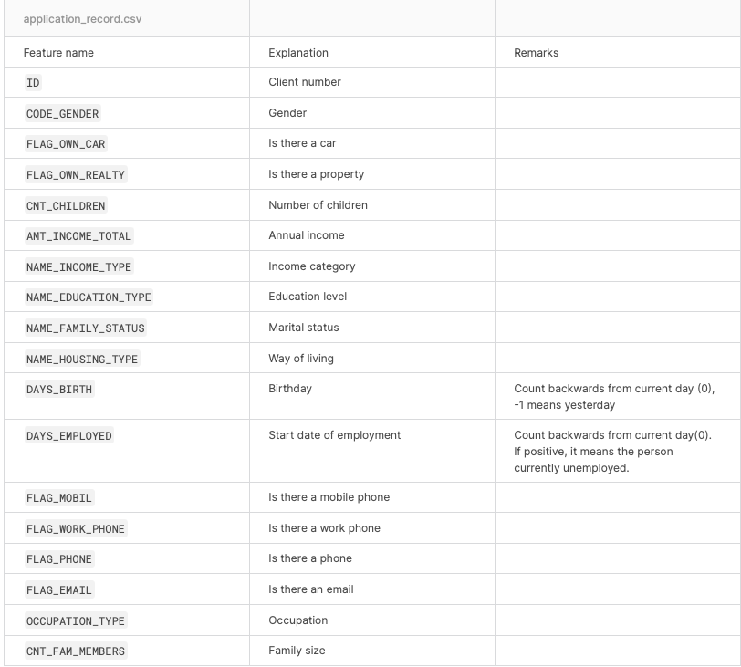

```python
app_df=pd.read_csv('application_record.csv')
app_df.head(10)
```

|  | ID | CODE_GENDER | FLAG_OWN_CAR | FLAG_OWN_REALTY | CNT_CHILDREN | AMT_INCOME_TOTAL | NAME_INCOME_TYPE | NAME_EDUCATION_TYPE | NAME_FAMILY_STATUS | NAME_HOUSING_TYPE | DAYS_BIRTH | DAYS_EMPLOYED | FLAG_MOBIL | FLAG_WORK_PHONE | FLAG_PHONE | FLAG_EMAIL | OCCUPATION_TYPE | CNT_FAM_MEMBERS |
| --- | --- | --- | --- | --- | --- | --- | --- | --- | --- | --- | --- | --- | --- | --- | --- | --- | --- | --- |
| 0 | 5008804 | M | Y | Y | 0 | 427500.0 | Working | Higher education | Civil marriage | Rented apartment | -12005 | -4542 | 1 | 1 | 0 | 0 | NaN | 2.0 |
| 1 | 5008805 | M | Y | Y | 0 | 427500.0 | Working | Higher education | Civil marriage | Rented apartment | -12005 | -4542 | 1 | 1 | 0 | 0 | NaN | 2.0 |
| 2 | 5008806 | M | Y | Y | 0 | 112500.0 | Working | Secondary / secondary special | Married | House / apartment | -21474 | -1134 | 1 | 0 | 0 | 0 | Security staff | 2.0 |
| 3 | 5008808 | F | N | Y | 0 | 270000.0 | Commercial associate | Secondary / secondary special | Single / not married | House / apartment | -19110 | -3051 | 1 | 0 | 1 | 1 | Sales staff | 1.0 |
| 4 | 5008809 | F | N | Y | 0 | 270000.0 | Commercial associate | Secondary / secondary special | Single / not married | House / apartment | -19110 | -3051 | 1 | 0 | 1 | 1 | Sales staff | 1.0 |
| 5 | 5008810 | F | N | Y | 0 | 270000.0 | Commercial associate | Secondary / secondary special | Single / not married | House / apartment | -19110 | -3051 | 1 | 0 | 1 | 1 | Sales staff | 1.0 |
| 6 | 5008811 | F | N | Y | 0 | 270000.0 | Commercial associate | Secondary / secondary special | Single / not married | House / apartment | -19110 | -3051 | 1 | 0 | 1 | 1 | Sales staff | 1.0 |
| 7 | 5008812 | F | N | Y | 0 | 283500.0 | Pensioner | Higher education | Separated | House / apartment | -22464 | 365243 | 1 | 0 | 0 | 0 | NaN | 1.0 |
| 8 | 5008813 | F | N | Y | 0 | 283500.0 | Pensioner | Higher education | Separated | House / apartment | -22464 | 365243 | 1 | 0 | 0 | 0 | NaN | 1.0 |
| 9 | 5008814 | F | N | Y | 0 | 283500.0 | Pensioner | Higher education | Separated | House / apartment | -22464 | 365243 | 1 | 0 | 0 | 0 | NaN | 1.0 |

### Credit Records

```python
#Check for any null values
crd_df.isnull().value_counts()

#No empty values
```

```
ID     MONTHS_BALANCE  STATUS
False  False           False     1048575
dtype: int64
```

```python
crd_df.shape

# 1.04M rows with 3 columns
```

```
(1048575, 3)
```

```python
crd_df.columns
```

```
Index(['ID', 'MONTHS_BALANCE', 'STATUS'], dtype='object')
```

```python
crd_df.nunique()

# Some IDs repeat. Same customer appears more than once
```

```
ID                45985
MONTHS_BALANCE       61
STATUS                8
dtype: int64
```

```python
crd_df.MONTHS_BALANCE.value_counts()
```

```
-1     34436
-2     34209
 0     33856
-3     33854
-4     33365
       ...
-56     2109
-57     1649
-58     1255
-59      820
-60      415
Name: MONTHS_BALANCE, Length: 61, dtype: int64
```

```python
crd_df.MONTHS_BALANCE.isnull().value_counts()

# Every month there is data
```

```
False    1048575
Name: MONTHS_BALANCE, dtype: int64
```

```python
crd_df.STATUS.value_counts()

# Every pmt category there is data
```

```
C    442031
0    383120
X    209230
1     11090
5      1693
2       868
3       320
4       223
Name: STATUS, dtype: int64
```

```python
crd_df.describe()

# Values look fine
```

|  | ID | MONTHS_BALANCE |
| --- | --- | --- |
| count | 1.048575e+06 | 1.048575e+06 |
| mean | 5.068286e+06 | -1.913700e+01 |
| std | 4.615058e+04 | 1.402350e+01 |
| min | 5.001711e+06 | -6.000000e+01 |
| 25% | 5.023644e+06 | -2.900000e+01 |
| 50% | 5.062104e+06 | -1.700000e+01 |
| 75% | 5.113856e+06 | -7.000000e+00 |
| max | 5.150487e+06 | 0.000000e+00 |

```python
#Remap data to make it simplier for analysis

# 1 if Category C,X, 0 if Category 0,1,2,3,4,5
# 1 is the probabilty person will payback (1 non defaulter, 0 defaulter)
crd_df['c_score']=crd_df.STATUS.map({"C":1, "X":1, '0':0, '1':0, '2':0,'3':0, '4':0, '5':0})

print(crd_df.c_score.value_counts())

crd_df.head()
```

```
1    651261
0    397314
Name: c_score, dtype: int64
```

|  | ID | MONTHS_BALANCE | STATUS | c_score |
| --- | --- | --- | --- | --- |
| 0 | 5001711 | 0 | X | 1 |
| 1 | 5001711 | -1 | 0 | 0 |
| 2 | 5001711 | -2 | 0 | 0 |
| 3 | 5001711 | -3 | 0 | 0 |
| 4 | 5001712 | 0 | C | 1 |

```python
pd.DataFrame({'ID':crd_df.ID, 'c_score':crd_df.c_score})
```

|  | ID | c_score |
| --- | --- | --- |
| 0 | 5001711 | 1 |
| 1 | 5001711 | 0 |
| 2 | 5001711 | 0 |
| 3 | 5001711 | 0 |
| 4 | 5001712 | 1 |
| ... | ... | ... |
| 1048570 | 5150487 | 1 |
| 1048571 | 5150487 | 1 |
| 1048572 | 5150487 | 1 |
| 1048573 | 5150487 | 1 |
| 1048574 | 5150487 | 1 |

1048575 rows × 2 columns

```python
crd_df_cum_score = pd.DataFrame({'ID':crd_df.ID, 'c_score':crd_df.c_score}).groupby(by='ID').sum()
```

```python
import numpy as np

crd_df_cum_score['final_flag']=np.where(crd_df_cum_score.c_score==0, 1,0)
```

```python
#crd_df_cum_score.drop(columns=['c_score'], inplace=True)
crd_df_cum_score
```

| ID | final_flag |
| --- | --- |
| 5001711 | 0 |
| 5001712 | 0 |
| 5001713 | 0 |
| 5001714 | 0 |
| 5001715 | 0 |
| ... | ... |
| 5150482 | 0 |
| 5150483 | 0 |
| 5150484 | 0 |
| 5150485 | 1 |
| 5150487 | 0 |

45985 rows × 1 columns

### Applciation Records

```python
#Check for any null values

print(app_df.isnull().sum())

print(134203/438557)

#Occupation type hace 30% rows blank. Not a useful feature
```

```
ID                          0
CODE_GENDER                 0
FLAG_OWN_CAR                0
FLAG_OWN_REALTY             0
CNT_CHILDREN                0
AMT_INCOME_TOTAL            0
NAME_INCOME_TYPE            0
NAME_EDUCATION_TYPE         0
NAME_FAMILY_STATUS          0
NAME_HOUSING_TYPE           0
DAYS_BIRTH                  0
DAYS_EMPLOYED               0
FLAG_MOBIL                  0
FLAG_WORK_PHONE             0
FLAG_PHONE                  0
FLAG_EMAIL                  0
OCCUPATION_TYPE        134203
CNT_FAM_MEMBERS             0
dtype: int64
0.30601039317580153
```

```python
app_df.OCCUPATION_TYPE.unique()
```

```
array([nan, 'Security staff', 'Sales staff', 'Accountants', 'Laborers',
       'Managers', 'Drivers', 'Core staff', 'High skill tech staff',
       'Cleaning staff', 'Private service staff', 'Cooking staff',
       'Low-skill Laborers', 'Medicine staff', 'Secretaries',
       'Waiters/barmen staff', 'HR staff', 'Realty agents', 'IT staff'],
      dtype=object)
```

```python
app_df.shape
```

```
(438557, 18)
```

```python
app_df.nunique()

# Some unique ID is smaller than shpae. Some repeated IDs.
```

```
ID                     438510
CODE_GENDER                 2
FLAG_OWN_CAR                2
FLAG_OWN_REALTY             2
CNT_CHILDREN               12
AMT_INCOME_TOTAL          866
NAME_INCOME_TYPE            5
NAME_EDUCATION_TYPE         5
NAME_FAMILY_STATUS          5
NAME_HOUSING_TYPE           6
DAYS_BIRTH              16379
DAYS_EMPLOYED            9406
FLAG_MOBIL                  1
FLAG_WORK_PHONE             2
FLAG_PHONE                  2
FLAG_EMAIL                  2
OCCUPATION_TYPE            18
CNT_FAM_MEMBERS            13
dtype: int64
```

```python
# Check the duplicated rows. Drop all diplicates because have problems joining tables

#app_df.dtypes

app_df[app_df.duplicated('ID',keep= False)].sort_values(by='ID', ascending=True)
#app_df.drop_duplicates(subset=['ID'], inplace=True, keep = False)

app_df.ID.nunique()
```

```
438463
```

```python
#Describe Data

app_df.describe()

#Children max children looks too high
```

|  | ID | CNT_CHILDREN | AMT_INCOME_TOTAL | DAYS_BIRTH | DAYS_EMPLOYED | FLAG_MOBIL | FLAG_WORK_PHONE | FLAG_PHONE | FLAG_EMAIL | CNT_FAM_MEMBERS |
| --- | --- | --- | --- | --- | --- | --- | --- | --- | --- | --- |
| count | 4.384630e+05 | 438463.000000 | 4.384630e+05 | 438463.000000 | 438463.000000 | 438463.0 | 438463.000000 | 438463.000000 | 438463.000000 | 438463.000000 |
| mean | 6.021894e+06 | 0.427384 | 1.875220e+05 | -15997.934334 | 60564.534488 | 1.0 | 0.206129 | 0.287762 | 0.108196 | 2.194461 |
| std | 5.713554e+05 | 0.724879 | 1.100832e+05 | 4185.044293 | 138768.684097 | 0.0 | 0.404525 | 0.452720 | 0.310628 | 0.897194 |
| min | 5.008804e+06 | 0.000000 | 2.610000e+04 | -25201.000000 | -17531.000000 | 1.0 | 0.000000 | 0.000000 | 0.000000 | 1.000000 |
| 25% | 5.609340e+06 | 0.000000 | 1.215000e+05 | -19484.000000 | -3103.000000 | 1.0 | 0.000000 | 0.000000 | 0.000000 | 2.000000 |
| 50% | 6.047690e+06 | 0.000000 | 1.611000e+05 | -15630.000000 | -1468.000000 | 1.0 | 0.000000 | 0.000000 | 0.000000 | 2.000000 |
| 75% | 6.454118e+06 | 1.000000 | 2.250000e+05 | -12514.000000 | -371.000000 | 1.0 | 0.000000 | 1.000000 | 0.000000 | 3.000000 |
| max | 7.999952e+06 | 19.000000 | 6.750000e+06 | -7489.000000 | 365243.000000 | 1.0 | 1.000000 | 1.000000 | 1.000000 | 20.000000 |

```python
# For Days_Employed, if positive, person is unemployed. Convert positive values to 0

app_df.DAYS_EMPLOYED[app_df.DAYS_EMPLOYED>=0]=0
app_df.DAYS_EMPLOYED.describe()
```

```
count    438463.000000
mean      -2172.597955
std        2397.492776
min      -17531.000000
25%       -3103.000000
50%       -1468.000000
75%        -371.000000
max           0.000000
Name: DAYS_EMPLOYED, dtype: float64
```

```python
#Convert DAYS to years

convert_to_years_ls = ['DAYS_BIRTH','DAYS_EMPLOYED']

for i in convert_to_years_ls:
    app_df[i]=(app_df[i]/-365).round(1).abs()

app_df.rename(columns={'DAYS_BIRTH': 'YRS_BIRTH', 'DAYS_EMPLOYED': 'YRS_EMPLOYED'}, inplace=True)

app_df.head()
```

|  | ID | CODE_GENDER | FLAG_OWN_CAR | FLAG_OWN_REALTY | CNT_CHILDREN | AMT_INCOME_TOTAL | NAME_INCOME_TYPE | NAME_EDUCATION_TYPE | NAME_FAMILY_STATUS | NAME_HOUSING_TYPE | YRS_BIRTH | YRS_EMPLOYED | FLAG_MOBIL | FLAG_WORK_PHONE | FLAG_PHONE | FLAG_EMAIL | OCCUPATION_TYPE | CNT_FAM_MEMBERS |
| --- | --- | --- | --- | --- | --- | --- | --- | --- | --- | --- | --- | --- | --- | --- | --- | --- | --- | --- |
| 0 | 5008804 | M | Y | Y | 0 | 427500.0 | Working | Higher education | Civil marriage | Rented apartment | 32.9 | 12.4 | 1 | 1 | 0 | 0 | NaN | 2.0 |
| 1 | 5008805 | M | Y | Y | 0 | 427500.0 | Working | Higher education | Civil marriage | Rented apartment | 32.9 | 12.4 | 1 | 1 | 0 | 0 | NaN | 2.0 |
| 2 | 5008806 | M | Y | Y | 0 | 112500.0 | Working | Secondary / secondary special | Married | House / apartment | 58.8 | 3.1 | 1 | 0 | 0 | 0 | Security staff | 2.0 |
| 3 | 5008808 | F | N | Y | 0 | 270000.0 | Commercial associate | Secondary / secondary special | Single / not married | House / apartment | 52.4 | 8.4 | 1 | 0 | 1 | 1 | Sales staff | 1.0 |
| 4 | 5008809 | F | N | Y | 0 | 270000.0 | Commercial associate | Secondary / secondary special | Single / not married | House / apartment | 52.4 | 8.4 | 1 | 0 | 1 | 1 | Sales staff | 1.0 |

```python
#Remap data Gender, Car, Property

# 1 if Male, 0 if Female
app_df['CODE_GENDER']=app_df.CODE_GENDER.map({"M":1, "F":0,})

# 1 if own Car, 0 if no car
app_df['FLAG_OWN_CAR']=app_df.FLAG_OWN_CAR.map({"Y":1, "N":0,})

# 1 if own Property, 0 if no Property
app_df['FLAG_OWN_REALTY']=app_df.FLAG_OWN_REALTY.map({"Y":1, "N":0,})


app_df.head()
```

|  | ID | CODE_GENDER | FLAG_OWN_CAR | FLAG_OWN_REALTY | CNT_CHILDREN | AMT_INCOME_TOTAL | NAME_INCOME_TYPE | NAME_EDUCATION_TYPE | NAME_FAMILY_STATUS | NAME_HOUSING_TYPE | YRS_BIRTH | YRS_EMPLOYED | FLAG_MOBIL | FLAG_WORK_PHONE | FLAG_PHONE | FLAG_EMAIL | OCCUPATION_TYPE | CNT_FAM_MEMBERS |
| --- | --- | --- | --- | --- | --- | --- | --- | --- | --- | --- | --- | --- | --- | --- | --- | --- | --- | --- |
| 0 | 5008804 | 1 | 1 | 1 | 0 | 427500.0 | Working | Higher education | Civil marriage | Rented apartment | 32.9 | 12.4 | 1 | 1 | 0 | 0 | NaN | 2.0 |
| 1 | 5008805 | 1 | 1 | 1 | 0 | 427500.0 | Working | Higher education | Civil marriage | Rented apartment | 32.9 | 12.4 | 1 | 1 | 0 | 0 | NaN | 2.0 |
| 2 | 5008806 | 1 | 1 | 1 | 0 | 112500.0 | Working | Secondary / secondary special | Married | House / apartment | 58.8 | 3.1 | 1 | 0 | 0 | 0 | Security staff | 2.0 |
| 3 | 5008808 | 0 | 0 | 1 | 0 | 270000.0 | Commercial associate | Secondary / secondary special | Single / not married | House / apartment | 52.4 | 8.4 | 1 | 0 | 1 | 1 | Sales staff | 1.0 |
| 4 | 5008809 | 0 | 0 | 1 | 0 | 270000.0 | Commercial associate | Secondary / secondary special | Single / not married | House / apartment | 52.4 | 8.4 | 1 | 0 | 1 | 1 | Sales staff | 1.0 |

```python
# Remove Outliers for Children Column

print(app_df.CNT_CHILDREN.value_counts())


q1 = app_df.CNT_CHILDREN.quantile(0.25)
q3 = app_df.CNT_CHILDREN.quantile(0.75)

iqr = q3 - q1
upper_bound = q3 +(1.5 * iqr)

print(upper_bound)  #remove rows with more than 5 children

app_df.drop(app_df[app_df.CNT_CHILDREN>5].index, inplace=True)

app_df.CNT_CHILDREN.describe()
```

```
0     304007
1      88509
2      39873
3       5429
4        486
5        133
7          9
9          5
12         4
6          4
14         3
19         1
Name: CNT_CHILDREN, dtype: int64
2.5
```

```
count    438437.000000
mean          0.426860
std           0.721251
min           0.000000
25%           0.000000
50%           0.000000
75%           1.000000
max           5.000000
Name: CNT_CHILDREN, dtype: float64
```

```
2.0    233846
1.0     84471
3.0     77112
4.0     37345
5.0      5080
6.0       459
7.0       124
Name: CNT_FAM_MEMBERS, dtype: int64
```

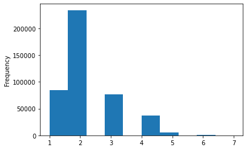

```python
# Checking FAM Members

app_df.CNT_FAM_MEMBERS.plot(kind="hist");

app_df.CNT_FAM_MEMBERS.value_counts()
```

## Combining 2 tables together - df2

```python
#Crd Table Row Count
print(crd_df_cum_score.shape)

#Inner Join table
df1=app_df.merge(crd_df_cum_score, how='inner', on='ID')

df1  #36,451 rows only -> some customers with credit score are not in the application records
```

```
(45985, 1)
```

|  | ID | CODE_GENDER | FLAG_OWN_CAR | FLAG_OWN_REALTY | CNT_CHILDREN | AMT_INCOME_TOTAL | NAME_INCOME_TYPE | NAME_EDUCATION_TYPE | NAME_FAMILY_STATUS | NAME_HOUSING_TYPE | YRS_BIRTH | YRS_EMPLOYED | FLAG_MOBIL | FLAG_WORK_PHONE | FLAG_PHONE | FLAG_EMAIL | OCCUPATION_TYPE | CNT_FAM_MEMBERS | final_flag |
| --- | --- | --- | --- | --- | --- | --- | --- | --- | --- | --- | --- | --- | --- | --- | --- | --- | --- | --- | --- |
| 0 | 5008804 | 1 | 1 | 1 | 0 | 427500.0 | Working | Higher education | Civil marriage | Rented apartment | 32.9 | 12.4 | 1 | 1 | 0 | 0 | NaN | 2.0 | 0 |
| 1 | 5008805 | 1 | 1 | 1 | 0 | 427500.0 | Working | Higher education | Civil marriage | Rented apartment | 32.9 | 12.4 | 1 | 1 | 0 | 0 | NaN | 2.0 | 0 |
| 2 | 5008806 | 1 | 1 | 1 | 0 | 112500.0 | Working | Secondary / secondary special | Married | House / apartment | 58.8 | 3.1 | 1 | 0 | 0 | 0 | Security staff | 2.0 | 0 |
| 3 | 5008808 | 0 | 0 | 1 | 0 | 270000.0 | Commercial associate | Secondary / secondary special | Single / not married | House / apartment | 52.4 | 8.4 | 1 | 0 | 1 | 1 | Sales staff | 1.0 | 0 |
| 4 | 5008809 | 0 | 0 | 1 | 0 | 270000.0 | Commercial associate | Secondary / secondary special | Single / not married | House / apartment | 52.4 | 8.4 | 1 | 0 | 1 | 1 | Sales staff | 1.0 | 0 |
| ... | ... | ... | ... | ... | ... | ... | ... | ... | ... | ... | ... | ... | ... | ... | ... | ... | ... | ... | ... |
| 36446 | 5149828 | 1 | 1 | 1 | 0 | 315000.0 | Working | Secondary / secondary special | Married | House / apartment | 47.5 | 6.6 | 1 | 0 | 0 | 0 | Managers | 2.0 | 0 |
| 36447 | 5149834 | 0 | 0 | 1 | 0 | 157500.0 | Commercial associate | Higher education | Married | House / apartment | 33.9 | 3.6 | 1 | 0 | 1 | 1 | Medicine staff | 2.0 | 0 |
| 36448 | 5149838 | 0 | 0 | 1 | 0 | 157500.0 | Pensioner | Higher education | Married | House / apartment | 33.9 | 3.6 | 1 | 0 | 1 | 1 | Medicine staff | 2.0 | 0 |
| 36449 | 5150049 | 0 | 0 | 1 | 0 | 283500.0 | Working | Secondary / secondary special | Married | House / apartment | 49.2 | 1.8 | 1 | 0 | 0 | 0 | Sales staff | 2.0 | 1 |
| 36450 | 5150337 | 1 | 0 | 1 | 0 | 112500.0 | Working | Secondary / secondary special | Single / not married | Rented apartment | 25.2 | 3.3 | 1 | 0 | 0 | 0 | Laborers | 1.0 | 1 |

36451 rows × 19 columns

```python
## Perform one hot encodign because some columns are categorical

#One hot encoding for NAME_INCOME_TYPE
income_type_dummies=pd.get_dummies(df1.NAME_INCOME_TYPE, prefix='income_type')
income_type_dummies.drop(income_type_dummies.columns[0],axis=1,inplace=True)

#One hot encoding for NAME_EDUCATION_TYPE
edu_type_dummies=pd.get_dummies(df1.NAME_EDUCATION_TYPE, prefix='edu_type')
edu_type_dummies.drop(edu_type_dummies.columns[0],axis=1,inplace=True)


#One hot encoding for NAME_FAMILY_STATUS
fam_status_dummies=pd.get_dummies(df1.NAME_FAMILY_STATUS, prefix='fam_status')
fam_status_dummies.drop(fam_status_dummies.columns[0],axis=1,inplace=True)


#One hot encoding for NAME_HOUSING_TYPE
hse_type_dummies=pd.get_dummies(df1.NAME_HOUSING_TYPE, prefix='hse_type')
hse_type_dummies.drop(hse_type_dummies.columns[0],axis=1,inplace=True)


#df2=pd.concat([df1,income_type_dummies,edu_type_dummies,fam_status_dummies,hse_type_dummies],axis=1)

#df2.head()
```

[output not shown]

5 rows × 36 columns

```python
#Drop columns that are unnecessary

print (df1.OCCUPATION_TYPE.isnull().sum()/df1.shape[0]) #since occupation type is 31% NaN, drop it

#df2.drop(columns=['NAME_INCOME_TYPE','NAME_EDUCATION_TYPE','NAME_FAMILY_STATUS','NAME_HOUSING_TYPE','OCCUPATION_TYPE'], inplace = True)

print(df2.columns)
df2.head()
```

```
0.3106361965378179
Index(['ID', 'CODE_GENDER', 'FLAG_OWN_CAR', 'FLAG_OWN_REALTY', 'CNT_CHILDREN',
       'AMT_INCOME_TOTAL', 'YRS_BIRTH', 'YRS_EMPLOYED', 'FLAG_MOBIL',
       'FLAG_WORK_PHONE', 'FLAG_PHONE', 'FLAG_EMAIL', 'CNT_FAM_MEMBERS',
       'final_flag', 'income_type_Pensioner', 'income_type_State servant',
       'income_type_Student', 'income_type_Working',
       'edu_type_Higher education', 'edu_type_Incomplete higher',
       'edu_type_Lower secondary', 'edu_type_Secondary / secondary special',
       'fam_status_Married', 'fam_status_Separated',
       'fam_status_Single / not married', 'fam_status_Widow',
       'hse_type_House / apartment', 'hse_type_Municipal apartment',
       'hse_type_Office apartment', 'hse_type_Rented apartment',
       'hse_type_With parents'],
      dtype='object')
```

|  | ID | CODE_GENDER | FLAG_OWN_CAR | FLAG_OWN_REALTY | CNT_CHILDREN | AMT_INCOME_TOTAL | YRS_BIRTH | YRS_EMPLOYED | FLAG_MOBIL | FLAG_WORK_PHONE | ... | edu_type_Secondary / secondary special | fam_status_Married | fam_status_Separated | fam_status_Single / not married | fam_status_Widow | hse_type_House / apartment | hse_type_Municipal apartment | hse_type_Office apartment | hse_type_Rented apartment | hse_type_With parents |
| --- | --- | --- | --- | --- | --- | --- | --- | --- | --- | --- | --- | --- | --- | --- | --- | --- | --- | --- | --- | --- | --- |
| 0 | 5008804 | 1 | 1 | 1 | 0 | 427500.0 | 32.9 | 12.4 | 1 | 1 | ... | 0 | 0 | 0 | 0 | 0 | 0 | 0 | 0 | 1 | 0 |
| 1 | 5008805 | 1 | 1 | 1 | 0 | 427500.0 | 32.9 | 12.4 | 1 | 1 | ... | 0 | 0 | 0 | 0 | 0 | 0 | 0 | 0 | 1 | 0 |
| 2 | 5008806 | 1 | 1 | 1 | 0 | 112500.0 | 58.8 | 3.1 | 1 | 0 | ... | 1 | 1 | 0 | 0 | 0 | 1 | 0 | 0 | 0 | 0 |
| 3 | 5008808 | 0 | 0 | 1 | 0 | 270000.0 | 52.4 | 8.4 | 1 | 0 | ... | 1 | 0 | 0 | 1 | 0 | 1 | 0 | 0 | 0 | 0 |
| 4 | 5008809 | 0 | 0 | 1 | 0 | 270000.0 | 52.4 | 8.4 | 1 | 0 | ... | 1 | 0 | 0 | 1 | 0 | 1 | 0 | 0 | 0 | 0 |

5 rows × 31 columns

## 2) Visualisation

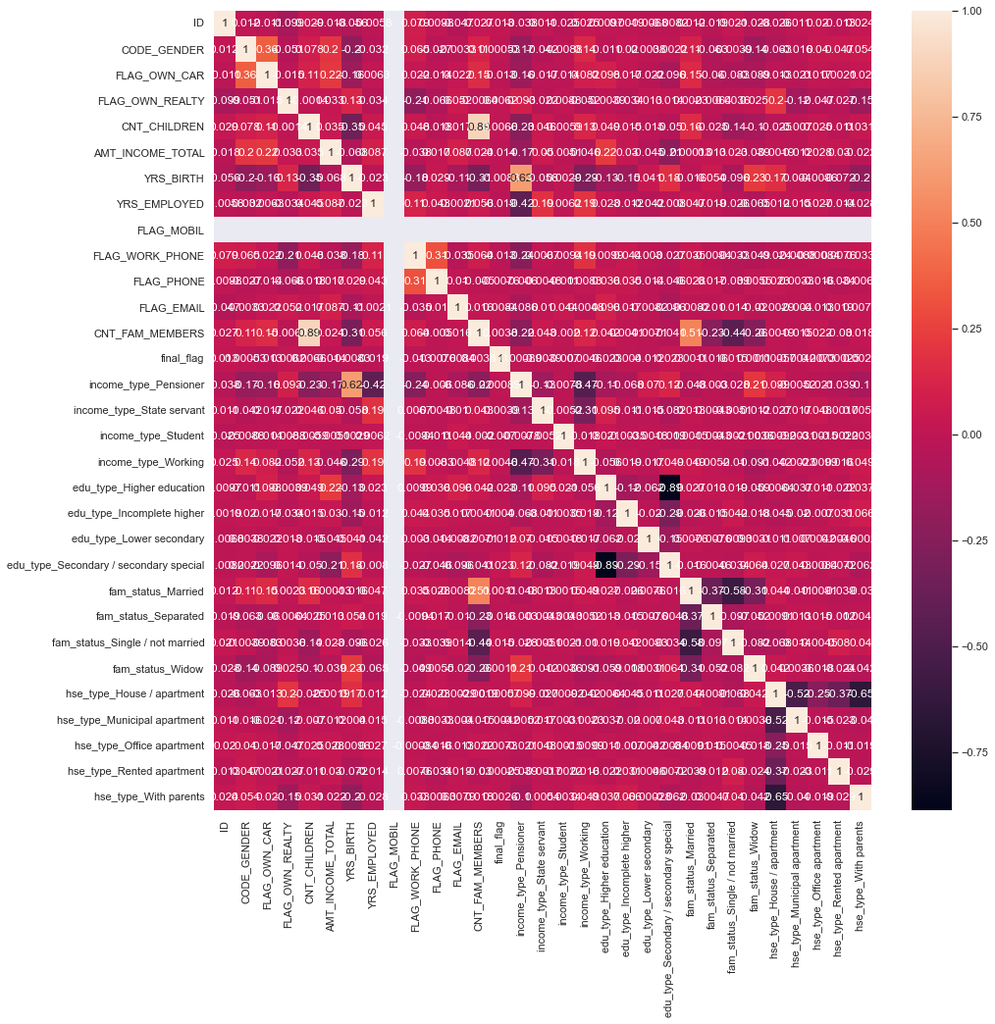

```python
import seaborn as sns
df2.corr()

sns.set(rc={'figure.figsize':(15,15)})
sns.heatmap(df2.corr(),annot=True);

#count of children and count of family memeber highly correlated. If use children, dont use family member and vice versa
```

```
final_flag        0     1
CNT_CHILDREN
0             21726  3475
1              6469  1023
2              2794   462
3               345    74
4                51    12
5                19     1
```

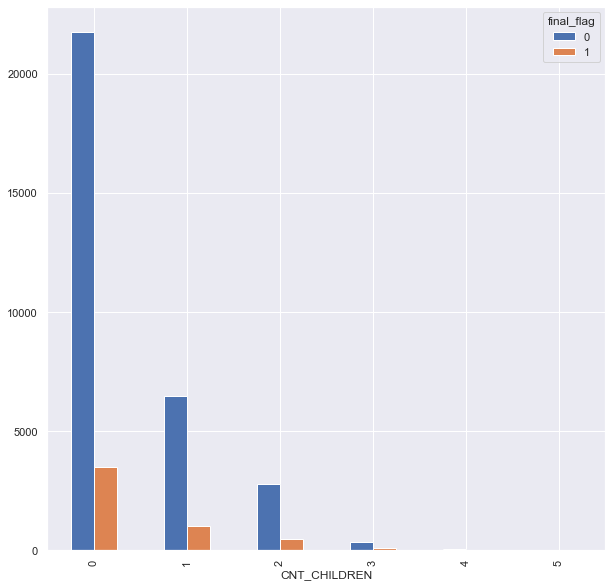

```python
# Comparing between children and whether customer will default or not

import matplotlib.pyplot as plt

print(pd.crosstab(df2.CNT_CHILDREN, df2.final_flag))

pd.crosstab(df2.CNT_CHILDREN, df2.final_flag).plot.bar(figsize=(10,10));
```

```python
df2.final_flag.value_counts() #Imbalanced dataset. 31k default vs 5k does not default
```

```
0    31404
1     5047
Name: final_flag, dtype: int64
```

If the data set in imbalance then In such cases, you get a pretty high accuracy just by predicting the majority class, but you fail to capture the minority class.

## 3) Logisitc Regression

a) Try with all features first

```python
#Take out ID
feature_cols_all=['CODE_GENDER', 'FLAG_OWN_CAR', 'FLAG_OWN_REALTY', 'CNT_CHILDREN',
       'AMT_INCOME_TOTAL', 'YRS_BIRTH', 'YRS_EMPLOYED', 'FLAG_MOBIL',
       'FLAG_WORK_PHONE', 'FLAG_PHONE', 'FLAG_EMAIL', 'CNT_FAM_MEMBERS','income_type_Pensioner', 'income_type_State servant',
       'income_type_Student', 'income_type_Working',
       'edu_type_Higher education', 'edu_type_Incomplete higher',
       'edu_type_Lower secondary', 'edu_type_Secondary / secondary special',
       'fam_status_Married', 'fam_status_Separated',
       'fam_status_Single / not married', 'fam_status_Widow',
       'hse_type_House / apartment', 'hse_type_Municipal apartment',
       'hse_type_Office apartment', 'hse_type_Rented apartment',
       'hse_type_With parents']

X_all = df2[feature_cols_all]
y_all = df2.final_flag
```

```python
#train test split (train : test is 70% : 30%)
from sklearn.model_selection import train_test_split

X_all_train,X_all_test,y_all_train,y_all_test = train_test_split(X_all,y_all,test_size=0.3,random_state=1)


#Scale the data
from sklearn.preprocessing import StandardScaler
scaler = StandardScaler()
X_all_train = scaler.fit_transform(X_all_train)
X_all_test = scaler.transform(X_all_test)


# Fit a logistic regression model on test and store the class predictions.
from sklearn.linear_model import LogisticRegression

logreg = LogisticRegression()

logreg.fit(X_all_train,y_all_train)
y_all_pred = logreg.predict(X_all_test)


# Print the coefficients.
print(logreg.intercept_)
print(list(zip(feature_cols_all, logreg.coef_)))
```

```
[-1.842939]
[('CODE_GENDER', array([ 0.00827322, -0.04691263, -0.00040279, -0.22369656, -0.0142354 ,
       -0.02676652, -0.05222749,  0.        , -0.0573116 , -0.02695658,
        0.03336216,  0.30270489, -0.00429731,  0.01502019, -0.10696648,
        0.03145429,  0.26066074,  0.13328106,  0.00920093,  0.35015547,
        0.00217162,  0.0211599 ,  0.15178035,  0.06067443,  0.10633016,
        0.05841699,  0.06916127,  0.02254244,  0.04058665]))]
```

```python
logreg.predict_proba(X_all_test)    #left column is 0 (Will default) vs 1 (Will not default)
```

```
array([[0.85104586, 0.14895414],
       [0.85169623, 0.14830377],
       [0.86213562, 0.13786438],
       ...,
       [0.88068129, 0.11931871],
       [0.89372829, 0.10627171],
       [0.85378587, 0.14621413]])
```

```python
# Get probability predictions.
logit_pred_proba_all = logreg.predict_proba(X_all_test)[:,1]


y_true=y_all_test
y_pred=logit_pred_proba_all > .18

from sklearn import linear_model, model_selection, metrics
metrics.confusion_matrix(y_true, y_pred)

#TN|FP
#------
#FN|TP
```

```
array([[9244,  170],
       [1493,   29]])
```

```python
#If threshold higher, not ablet to have any true positive
metrics.confusion_matrix(y_true, logit_pred_proba_all > .5)
```

```
array([[9414,    0],
       [1522,    0]])
```

```python
#Performance Metrics

from sklearn.metrics import roc_curve, auc, accuracy_score, precision_score,recall_score
fpr, tpr, thresholds = metrics.roc_curve(y_true,y_pred)

print("AUC Score: {}".format(metrics.auc(fpr, tpr)))
print("Accuracy Score: {}".format(accuracy_score(y_true,y_pred)))
print("Precision Score which is TP/TP+FP: {}".format(precision_score(y_true,y_pred)))
print("Recall which is TP/TP+FN: {}".format(recall_score(y_true,y_pred)))

#AUC score low. Not very able to differentiate between negative and postive class

#Low score due to imbalanced dataset :(
```

```
AUC Score: 0.500497832651736
Accuracy Score: 0.8479334308705194
Precision Score which is TP/TP+FP: 0.1457286432160804
Recall which is TP/TP+FN: 0.019053876478318004
```

b) Try with feature selection using decision tree

```python
from sklearn.tree import DecisionTreeClassifier

treeclf = DecisionTreeClassifier(random_state=1,max_depth=40)
treeclf.fit(X_all, y_all)


# Use leave-one-out cross-validation (LOOCV) to estimate the RMSE for this model.#CV for decision tree
from sklearn.model_selection import cross_val_score
scores = cross_val_score(treeclf, X_all, y_all, cv=14, scoring='neg_mean_squared_error')
np.mean(np.sqrt(-scores))

pd.DataFrame({'feature':feature_cols_all, 'importance':treeclf.feature_importances_}).sort_values(by='importance', ascending=False)
```

|  | feature | importance |
| --- | --- | --- |
| 5 | YRS_BIRTH | 0.298729 |
| 6 | YRS_EMPLOYED | 0.189536 |
| 4 | AMT_INCOME_TOTAL | 0.169116 |
| 11 | CNT_FAM_MEMBERS | 0.036600 |
| 0 | CODE_GENDER | 0.032223 |
| 1 | FLAG_OWN_CAR | 0.027188 |
| 2 | FLAG_OWN_REALTY | 0.026164 |
| 15 | income_type_Working | 0.024761 |
| 3 | CNT_CHILDREN | 0.019095 |
| 8 | FLAG_WORK_PHONE | 0.018027 |
| 20 | fam_status_Married | 0.017529 |
| 22 | fam_status_Single / not married | 0.016318 |
| 16 | edu_type_Higher education | 0.013701 |
| 9 | FLAG_PHONE | 0.013493 |
| 10 | FLAG_EMAIL | 0.013349 |
| 13 | income_type_State servant | 0.011508 |
| 28 | hse_type_With parents | 0.010220 |
| 17 | edu_type_Incomplete higher | 0.009135 |
| 21 | fam_status_Separated | 0.008706 |
| 19 | edu_type_Secondary / secondary special | 0.008634 |
| 24 | hse_type_House / apartment | 0.008313 |
| 23 | fam_status_Widow | 0.007768 |
| 25 | hse_type_Municipal apartment | 0.006353 |
| 27 | hse_type_Rented apartment | 0.004309 |
| 12 | income_type_Pensioner | 0.003627 |
| 26 | hse_type_Office apartment | 0.003008 |
| 18 | edu_type_Lower secondary | 0.002591 |
| 7 | FLAG_MOBIL | 0.000000 |
| 14 | income_type_Student | 0.000000 |

```python
#Take top 15 and retrain logreg

feature_impt=pd.DataFrame({'feature':feature_cols_all, 'importance':treeclf.feature_importances_}).sort_values(by='importance', ascending=False)

feature_col_2=feature_impt.feature[0:16].tolist()
```

```python
X_all = df2[feature_col_2]
y_all = df2.final_flag

#train test split (train : test is 70% : 30%)
from sklearn.model_selection import train_test_split

X_all_train,X_all_test,y_all_train,y_all_test = train_test_split(X_all,y_all,test_size=0.3,random_state=1)


#Scale the data
from sklearn.preprocessing import StandardScaler
scaler = StandardScaler()
X_all_train = scaler.fit_transform(X_all_train)
X_all_test = scaler.transform(X_all_test)


# Fit a logistic regression model on test and store the class predictions.
from sklearn.linear_model import LogisticRegression

logreg = LogisticRegression()

logreg.fit(X_all_train,y_all_train)
y_all_pred = logreg.predict(X_all_test)


# Print the coefficients.
print(logreg.intercept_)
print(list(zip(feature_col_2, logreg.coef_)))
```

```
[-1.83819797]
[('YRS_BIRTH', array([-0.01667903, -0.04847952, -0.01195642,  0.14759127,  0.00705375,
       -0.04513223,  0.00137457,  0.03358166, -0.09689751, -0.05743492,
       -0.00212346,  0.08841917, -0.07016617, -0.02619361,  0.03236677,
        0.01896426]))]
```

```python
# Get probability predictions.
logit_pred_proba_all = logreg.predict_proba(X_all_test)[:,1]


y_true=y_all_test
y_pred=logit_pred_proba_all > .18

from sklearn import linear_model, model_selection, metrics
metrics.confusion_matrix(y_true, y_pred)

#TN|FP
#------
#FN|TP
```

```
array([[9363,   51],
       [1509,   13]])
```

```python
#Performance Metrics

from sklearn.metrics import roc_curve, auc, accuracy_score, precision_score,recall_score
fpr, tpr, thresholds = metrics.roc_curve(y_true,y_pred)

print("AUC Score: {}".format(metrics.auc(fpr, tpr)))
print("Accuracy Score: {}".format(accuracy_score(y_true,y_pred)))
print("Precision Score which is TP/TP+FP: {}".format(precision_score(y_true,y_pred)))
print("Recall which is TP/TP+FN: {}".format(recall_score(y_true,y_pred)))

#AUC score low. Not very able to differentiate between negative and postive class

#Low score due to imbalanced dataset :(
```

```
AUC Score: 0.5015619647758099
Accuracy Score: 0.8573518653986832
Precision Score which is TP/TP+FP: 0.203125
Recall which is TP/TP+FN: 0.008541392904073587
```

**Conclusion** : AUC, Accuracy Score, Precision score actually improved withe extracting more important feature

## 4) Trying with KNN

```python
from sklearn.neighbors import KNeighborsClassifier
from sklearn.model_selection import train_test_split
from sklearn import metrics

X_all = df2[feature_cols_all]
y_all = df2.final_flag

X_train, X_test, y_train, y_test = train_test_split(X_all, y_all, random_state=1)   #too long to run 500K rows
```

```python
#Try with 1 neighbour
knn = KNeighborsClassifier(n_neighbors=1)
knn.fit(X_train, y_train)

y_pred_knn = knn.predict(X_test)

y_pred_knn
```

```
array([0, 0, 0, ..., 0, 0, 0])
```

```python
#Performance Metrics

y_true=y_test
y_pred=y_pred_knn

from sklearn.metrics import roc_curve, auc, accuracy_score, precision_score,recall_score
fpr, tpr, thresholds = metrics.roc_curve(y_true,y_pred)

print("AUC Score: {}".format(metrics.auc(fpr, tpr)))
print("Accuracy Score: {}".format(accuracy_score(y_true,y_pred)))
print("Precision Score which is TP/TP+FP: {}".format(precision_score(y_true,y_pred)))
print("Recall which is TP/TP+FN: {}".format(recall_score(y_true,y_pred)))
```

```
AUC Score: 0.5878262483655682
Accuracy Score: 0.7991879732250631
Precision Score which is TP/TP+FP: 0.2824601366742597
Recall which is TP/TP+FN: 0.29594272076372313
```

```python
#Try with different n_neighbors

auc = []
precision = []
accuracy = []
recall = []

for k in range(1,30):
    knn = KNeighborsClassifier(n_neighbors=k)
    knn.fit(X_train,y_train)
    pred = knn.predict(X_test)
    fpr, tpr, threshold = metrics.roc_curve(y_test,pred)
    aucs = metrics.auc(fpr, tpr)
    accuracys = accuracy_score(y_test,pred)
    precisions = precision_score(y_test,pred)
    recalls = recall_score(y_test,pred)
    auc.append([k, aucs])
    precision.append([precisions])
    accuracy.append([accuracys])
    recall.append([recalls])
```

[output not shown]

```python
a=pd.DataFrame(auc,columns=['k','auc'])
b=pd.DataFrame(precision,columns=['precision'])
c=pd.DataFrame(accuracy,columns=['accuracy'])
d=pd.DataFrame(recall,columns=['recall'])

data = a.join(b)
data = data.join(c)
data = data.join(d)

data.head()
```

|  | k | auc | precision | accuracy | recall |
| --- | --- | --- | --- | --- | --- |
| 0 | 1 | 0.587826 | 0.282460 | 0.799188 | 0.295943 |
| 1 | 2 | 0.548591 | 0.436261 | 0.857127 | 0.122514 |
| 2 | 3 | 0.569084 | 0.343879 | 0.837156 | 0.198886 |
| 3 | 4 | 0.540859 | 0.482490 | 0.861078 | 0.098648 |
| 4 | 5 | 0.551789 | 0.401408 | 0.852848 | 0.136038 |

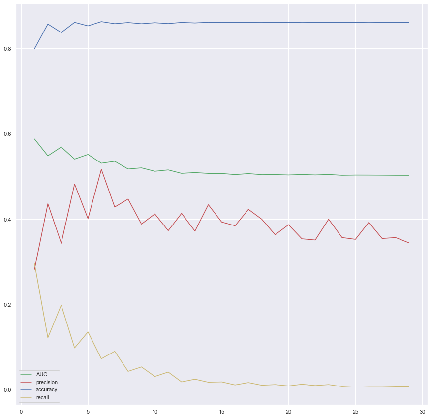

```python
plt.plot(data.k,data.auc,color='g', label='AUC');
plt.plot(data.k,data.precision,color='r', label='precision');
plt.plot(data.k,data.accuracy,color='b', label='accuracy');
plt.plot(data.k,data.recall,color='y', label='recall');

plt.legend()
plt.show()
```

```python
data.sort_values(by = ['precision'], ascending = False)  #use K=6 as best compromise
```

|  | k | auc | precision | accuracy | recall |
| --- | --- | --- | --- | --- | --- |
| 5 | 6 | 0.531122 | 0.516854 | 0.862724 | 0.073190 |
| 3 | 4 | 0.540859 | 0.482490 | 0.861078 | 0.098648 |
| 7 | 8 | 0.517550 | 0.447154 | 0.860639 | 0.043755 |
| 1 | 2 | 0.548591 | 0.436261 | 0.857127 | 0.122514 |
| 13 | 14 | 0.507239 | 0.433962 | 0.861297 | 0.018298 |
| 6 | 7 | 0.535672 | 0.428571 | 0.857895 | 0.090692 |
| 16 | 17 | 0.506842 | 0.423077 | 0.861187 | 0.017502 |
| 11 | 12 | 0.507383 | 0.413793 | 0.860968 | 0.019093 |
| 9 | 10 | 0.512283 | 0.412371 | 0.860200 | 0.031822 |
| 4 | 5 | 0.551789 | 0.401408 | 0.852848 | 0.136038 |
| 22 | 23 | 0.504837 | 0.400000 | 0.861187 | 0.012729 |
| 17 | 18 | 0.504232 | 0.400000 | 0.861297 | 0.011138 |
| 14 | 15 | 0.507192 | 0.393443 | 0.860639 | 0.019093 |
| 25 | 26 | 0.503294 | 0.392857 | 0.861407 | 0.008751 |
| 8 | 9 | 0.520238 | 0.388571 | 0.857786 | 0.054097 |
| 19 | 20 | 0.503564 | 0.387097 | 0.861297 | 0.009547 |
| 15 | 16 | 0.504439 | 0.384615 | 0.861078 | 0.011933 |
| 10 | 11 | 0.515417 | 0.373239 | 0.858115 | 0.042164 |
| 12 | 13 | 0.509292 | 0.372093 | 0.859651 | 0.025457 |
| 18 | 19 | 0.504582 | 0.363636 | 0.860748 | 0.012729 |
| 27 | 28 | 0.502832 | 0.357143 | 0.861187 | 0.007955 |
| 23 | 24 | 0.502832 | 0.357143 | 0.861187 | 0.007955 |
| 26 | 27 | 0.503103 | 0.354839 | 0.861078 | 0.008751 |
| 20 | 21 | 0.504789 | 0.354167 | 0.860529 | 0.013524 |
| 24 | 25 | 0.503373 | 0.352941 | 0.860968 | 0.009547 |
| 21 | 22 | 0.503644 | 0.351351 | 0.860858 | 0.010342 |
| 28 | 29 | 0.502768 | 0.344828 | 0.861078 | 0.007955 |
| 2 | 3 | 0.569084 | 0.343879 | 0.837156 | 0.198886 |
| 0 | 1 | 0.587826 | 0.282460 | 0.799188 | 0.295943 |

## 5) Trying with Decision Tree

```python
#Use all features
X_all = df2[feature_cols_all]
y_all = df2.final_flag

X_train, X_test, y_train, y_test = train_test_split(X_all, y_all, random_state=1)   #too long to run 500K rows
```

```python
# Fit a classification tree with max_depth=3 on all data.
from sklearn.tree import DecisionTreeClassifier

treeclf = DecisionTreeClassifier(max_depth=3, random_state=1)
treeclf.fit(X_train, y_train)

y_true = y_test
y_pred = treeclf.predict(X_test)
```

[output not shown]

```python
# Performance metric

pr, tpr, thresholds = metrics.roc_curve(y_true,y_pred)

print("AUC Score: {}".format(metrics.auc(fpr, tpr)))
print("Accuracy Score: {}".format(accuracy_score(y_true,y_pred)))
print("Precision Score which is TP/TP+FP: {}".format(precision_score(y_true,y_pred)))
print("Recall which is TP/TP+FN: {}".format(recall_score(y_true,y_pred)))
```

```
AUC Score: 0.4995862781458456
Accuracy Score: 0.8621749149566553
Precision Score which is TP/TP+FP: 0.6666666666666666
Recall which is TP/TP+FN: 0.0015910898965791568
```

Precision is good. But AUC and recall is lower.

```
[(0.47039039404954924, 9),
 (0.4810711727749923, 8),
 (0.48441288278864203, 7),
 (0.49168410325674305, 6),
 (0.5015700554754707, 5),
 (0.5026578392435593, 4),
 (0.5118436249454695, 1),
 (0.5130180896448827, 2),
 (0.5142877094590667, 3)]
```

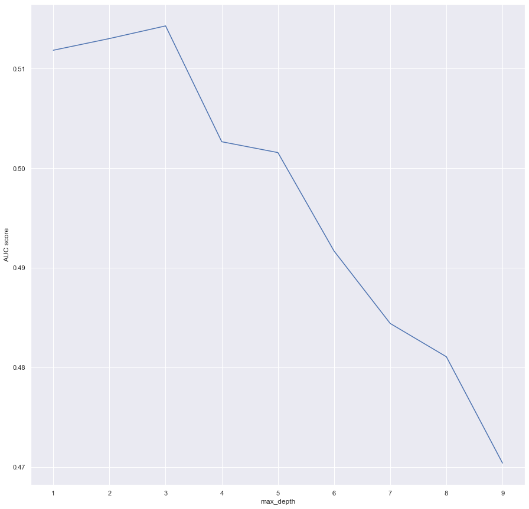

```python
# Try tuning max depth to see if there is improvement in performance + using LOOCV

max_depth_range = list(range(1, 10))
auc_scores = []

# Tuning with CV
for depth in max_depth_range:
    treeclf = DecisionTreeClassifier(max_depth=depth, random_state=1)
    scores = cross_val_score(treeclf, X_all,y_all, cv=30, scoring='roc_auc')
    auc_scores.append(np.mean(scores))


# Plot max_depth (x-axis) versus AUC (y-axis). Find the depth with highest AUC
plt.plot(max_depth_range, auc_scores);
plt.xlabel('max_depth');
plt.ylabel('AUC score');

sorted(zip(auc_scores, max_depth_range))
```

Turns out max depth of 3 is already the best

## 6) Trying with Random Forest

Ensemble model that bags. By building more trees, maybe AUC and other metrics can improve

```python
from sklearn.ensemble import RandomForestClassifier

X_train, X_test, y_train, y_test = train_test_split(X_all, y_all, random_state=1)

#Randomly try with 10 max features and 150 trees
rfclf = RandomForestClassifier(n_estimators=150, max_features=5, oob_score=True, random_state=1)
rfclf.fit(X_train, y_train)

print((rfclf.oob_score_)) #Number of correctly predicted rows from the out of bag sample.
```

```
0.8479040163874461
```

```python
# Performance metric

y_true = y_test
y_pred = rfclf.predict(X_test)

pr, tpr, thresholds = metrics.roc_curve(y_true,y_pred)

print("AUC Score: {}".format(metrics.auc(fpr, tpr)))
print("Accuracy Score: {}".format(accuracy_score(y_true,y_pred)))
print("Precision Score which is TP/TP+FP: {}".format(precision_score(y_true,y_pred)))
print("Recall which is TP/TP+FN: {}".format(recall_score(y_true,y_pred)))
```

```
AUC Score: 0.5986316242078982
Accuracy Score: 0.8494458465927796
Precision Score which is TP/TP+FP: 0.406807131280389
Recall which is TP/TP+FN: 0.19968178202068418
```

```python
# Compute feature importances.
rf_feature_impt=pd.DataFrame({'feature':feature_cols_all, 'importance':rfclf.feature_importances_}).sort_values(by='importance', ascending= False)

#Take top 15 and retrain Random Forest
rf_feature_impt

rf_feature_impt_ls = rf_feature_impt.feature[0:16].tolist()
```

```python
from sklearn.ensemble import RandomForestClassifier

X_rf = df2[rf_feature_impt_ls]

X_train, X_test, y_train, y_test = train_test_split(X_rf, y_all, random_state=1)

#Randomly try with 10 max features and 150 trees
rfclf = RandomForestClassifier(n_estimators=150, max_features=5, oob_score=True, random_state=1)
rfclf.fit(X_train, y_train)

print((rfclf.oob_score_)) #Number of correctly predicted rows from the out of bag sample.
```

```
0.8474650669397907
```

```python
# Performance metric

y_true = y_test
y_pred = rfclf.predict(X_test)

pr, tpr, thresholds = metrics.roc_curve(y_true,y_pred)

print("AUC Score: {}".format(metrics.auc(fpr, tpr)))
print("Accuracy Score: {}".format(accuracy_score(y_true,y_pred)))
print("Precision Score which is TP/TP+FP: {}".format(precision_score(y_true,y_pred)))
print("Recall which is TP/TP+FN: {}".format(recall_score(y_true,y_pred)))
```

```
AUC Score: 0.5986316242078982
Accuracy Score: 0.8488971798529573
Precision Score which is TP/TP+FP: 0.40353697749196143
Recall which is TP/TP+FN: 0.19968178202068418
```

Not much difference after extracting important features

```python
#Try tuning max feature

feature_range = list(range(1, len(rf_feature_impt_ls)+1))

auc = []
precision = []
accuracy = []
recall = []

for feature in feature_range:
    rfclf = RandomForestClassifier(n_estimators=10, max_features=feature,random_state=1) #try with 10 trees to speed up
    rfclf.fit(X_train,y_train)
    pred = rfclf.predict(X_test)
    fpr, tpr, threshold = metrics.roc_curve(y_test,pred)
    aucs = metrics.auc(fpr, tpr)
    accuracys = accuracy_score(y_test,pred)
    precisions = precision_score(y_test,pred)
    recalls = recall_score(y_test,pred)
    auc.append([feature, aucs])
    precision.append([precisions])
    accuracy.append([accuracys])
    recall.append([recalls])
    print(feature)
```

```
1
2
3
4
5
6
7
8
9
10
11
12
13
14
15
16
```

```python
a=pd.DataFrame(auc,columns=['feature','auc'])
b=pd.DataFrame(precision,columns=['precision'])
c=pd.DataFrame(accuracy,columns=['accuracy'])
d=pd.DataFrame(recall,columns=['recall'])

data = a.join(b)
data = data.join(c)
data = data.join(d)

data
```

|  | feature | auc | precision | accuracy | recall |
| --- | --- | --- | --- | --- | --- |
| 0 | 1 | 0.578504 | 0.393393 | 0.846483 | 0.208433 |
| 1 | 2 | 0.577835 | 0.392749 | 0.846483 | 0.206842 |
| 2 | 3 | 0.576165 | 0.391104 | 0.846483 | 0.202864 |
| 3 | 4 | 0.578122 | 0.401244 | 0.848129 | 0.205251 |
| 4 | 5 | 0.578551 | 0.396657 | 0.847141 | 0.207637 |
| 5 | 6 | 0.579379 | 0.404651 | 0.848568 | 0.207637 |
| 6 | 7 | 0.579204 | 0.400000 | 0.847690 | 0.208433 |
| 7 | 8 | 0.578806 | 0.399083 | 0.847580 | 0.207637 |
| 8 | 9 | 0.580842 | 0.407066 | 0.848787 | 0.210819 |
| 9 | 10 | 0.577978 | 0.391304 | 0.846154 | 0.207637 |
| 10 | 11 | 0.579251 | 0.392012 | 0.846044 | 0.210819 |
| 11 | 12 | 0.578917 | 0.403101 | 0.848349 | 0.206842 |
| 12 | 13 | 0.579506 | 0.394345 | 0.846483 | 0.210819 |
| 13 | 14 | 0.579363 | 0.395802 | 0.846812 | 0.210024 |
| 14 | 15 | 0.581463 | 0.404223 | 0.848129 | 0.213206 |
| 15 | 16 | 0.580047 | 0.405239 | 0.848568 | 0.209228 |

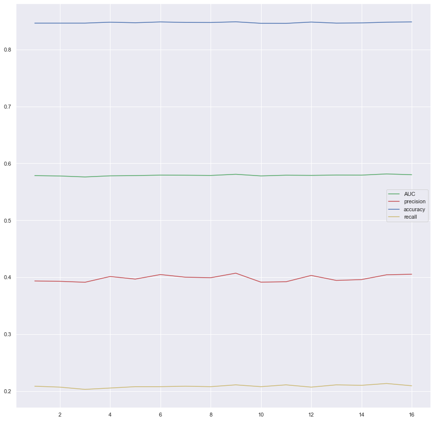

```python
plt.plot(data.feature,data.auc,color='g', label='AUC');
plt.plot(data.feature,data.precision,color='r', label='precision');
plt.plot(data.feature,data.accuracy,color='b', label='accuracy');
plt.plot(data.feature,data.recall,color='y', label='recall');

plt.legend()
plt.show()
```

```python
data.sort_values(by = ['auc'], ascending = False)   #Use 15 features will be the best!!!
```

|  | feature | auc | precision | accuracy | recall |
| --- | --- | --- | --- | --- | --- |
| 14 | 15 | 0.581463 | 0.404223 | 0.848129 | 0.213206 |
| 8 | 9 | 0.580842 | 0.407066 | 0.848787 | 0.210819 |
| 15 | 16 | 0.580047 | 0.405239 | 0.848568 | 0.209228 |
| 12 | 13 | 0.579506 | 0.394345 | 0.846483 | 0.210819 |
| 5 | 6 | 0.579379 | 0.404651 | 0.848568 | 0.207637 |
| 13 | 14 | 0.579363 | 0.395802 | 0.846812 | 0.210024 |
| 10 | 11 | 0.579251 | 0.392012 | 0.846044 | 0.210819 |
| 6 | 7 | 0.579204 | 0.400000 | 0.847690 | 0.208433 |
| 11 | 12 | 0.578917 | 0.403101 | 0.848349 | 0.206842 |
| 7 | 8 | 0.578806 | 0.399083 | 0.847580 | 0.207637 |
| 4 | 5 | 0.578551 | 0.396657 | 0.847141 | 0.207637 |
| 0 | 1 | 0.578504 | 0.393393 | 0.846483 | 0.208433 |
| 3 | 4 | 0.578122 | 0.401244 | 0.848129 | 0.205251 |
| 9 | 10 | 0.577978 | 0.391304 | 0.846154 | 0.207637 |
| 1 | 2 | 0.577835 | 0.392749 | 0.846483 | 0.206842 |
| 2 | 3 | 0.576165 | 0.391104 | 0.846483 | 0.202864 |

```python
#Try tuning number of trees


tree_range = list(range(150,250, 10))

auc = []
precision = []
accuracy = []
recall = []

for tree in tree_range:
    rfclf = RandomForestClassifier(n_estimators=tree, max_features=5,random_state=1) #try with 5 features to speed up
    rfclf.fit(X_train,y_train)
    pred = rfclf.predict(X_test)
    fpr, tpr, threshold = metrics.roc_curve(y_test,pred)
    aucs = metrics.auc(fpr, tpr)
    accuracys = accuracy_score(y_test,pred)
    precisions = precision_score(y_test,pred)
    recalls = recall_score(y_test,pred)
    auc.append([tree, aucs])
    precision.append([precisions])
    accuracy.append([accuracys])
    recall.append([recalls])
    print(tree)
```

```
150
160
170
180
190
200
210
220
230
240
```

```python
a=pd.DataFrame(auc,columns=['feature','auc'])
b=pd.DataFrame(precision,columns=['precision'])
c=pd.DataFrame(accuracy,columns=['accuracy'])
d=pd.DataFrame(recall,columns=['recall'])

data = a.join(b)
data = data.join(c)
data = data.join(d)

data
```

|  | feature | auc | precision | accuracy | recall |
| --- | --- | --- | --- | --- | --- |
| 0 | 150 | 0.576228 | 0.403537 | 0.848897 | 0.199682 |
| 1 | 160 | 0.576801 | 0.409462 | 0.849885 | 0.199682 |
| 2 | 170 | 0.576626 | 0.404494 | 0.849007 | 0.200477 |
| 3 | 180 | 0.574940 | 0.405941 | 0.849556 | 0.195704 |
| 4 | 190 | 0.576419 | 0.405493 | 0.849226 | 0.199682 |
| 5 | 200 | 0.576212 | 0.406504 | 0.849446 | 0.198886 |
| 6 | 210 | 0.575751 | 0.404878 | 0.849226 | 0.198091 |
| 7 | 220 | 0.575687 | 0.404221 | 0.849117 | 0.198091 |
| 8 | 230 | 0.575878 | 0.406199 | 0.849446 | 0.198091 |
| 9 | 240 | 0.576547 | 0.406807 | 0.849446 | 0.199682 |

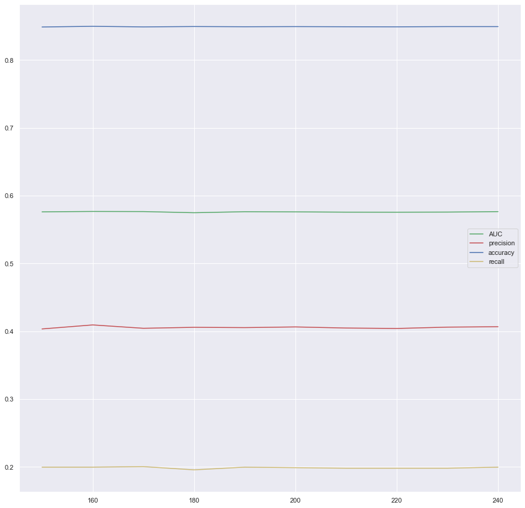

```python
plt.plot(data.feature,data.auc,color='g', label='AUC');
plt.plot(data.feature,data.precision,color='r', label='precision');
plt.plot(data.feature,data.accuracy,color='b', label='accuracy');
plt.plot(data.feature,data.recall,color='y', label='recall');

plt.legend()
plt.show()
```

```python
data.sort_values(by = ['auc'], ascending = False)    #Since marginal gains, take 160
```

|  | feature | auc | precision | accuracy | recall |
| --- | --- | --- | --- | --- | --- |
| 1 | 160 | 0.576801 | 0.409462 | 0.849885 | 0.199682 |
| 2 | 170 | 0.576626 | 0.404494 | 0.849007 | 0.200477 |
| 9 | 240 | 0.576547 | 0.406807 | 0.849446 | 0.199682 |
| 4 | 190 | 0.576419 | 0.405493 | 0.849226 | 0.199682 |
| 0 | 150 | 0.576228 | 0.403537 | 0.848897 | 0.199682 |
| 5 | 200 | 0.576212 | 0.406504 | 0.849446 | 0.198886 |
| 8 | 230 | 0.575878 | 0.406199 | 0.849446 | 0.198091 |
| 6 | 210 | 0.575751 | 0.404878 | 0.849226 | 0.198091 |
| 7 | 220 | 0.575687 | 0.404221 | 0.849117 | 0.198091 |
| 3 | 180 | 0.574940 | 0.405941 | 0.849556 | 0.195704 |

```python
# Retrain with 160 trees, 15 features

from sklearn.ensemble import RandomForestClassifier

X_train, X_test, y_train, y_test = train_test_split(X_all, y_all, random_state=1)

#Randomly try with 15 max features and 160 trees
rfclf = RandomForestClassifier(n_estimators=160, max_features=15, oob_score=True, random_state=1)
rfclf.fit(X_train, y_train)

print((rfclf.oob_score_)) #Number of correctly predicted rows from the out of bag sample.
```

```
0.8470992757334114
```

```python
# Performance metric

y_true = y_test
y_pred = rfclf.predict(X_test)

pr, tpr, thresholds = metrics.roc_curve(y_true,y_pred)

print("AUC Score: {}".format(metrics.auc(fpr, tpr)))
print("Accuracy Score: {}".format(accuracy_score(y_true,y_pred)))
print("Precision Score which is TP/TP+FP: {}".format(precision_score(y_true,y_pred)))
print("Recall which is TP/TP+FN: {}".format(recall_score(y_true,y_pred)))
```

```
AUC Score: 0.5757510487097103
Accuracy Score: 0.8494458465927796
Precision Score which is TP/TP+FP: 0.4061990212071778
Recall which is TP/TP+FN: 0.19809069212410502
```

Cannot really beat 150 trees and 5 max features. Sticking to 150 trees and 5 max features to keep it simple

## Conclusion

Top Performer: 1) Random forest  
2) KNN/ Decision tree - if you looking for something more sensitive to TP then choose KNN. Otherwise is precision is priority then decision tree  
3) Logsitic REgerssion